# Risk Factor Analysis

## Outcome Variable

**Outcome Variable:** haz

## Predictor Variables

**Intervention Variable:** nrooms

**Adjustment Set:**

unadjusted

## Stratifying Variables

The analysis was stratified on these variable(s):

- agecat
- studyid
- country

## Data Summary

| agecat | studyid | country | nrooms | n_cell | n |
| --- | --- | --- | --- | --- | --- |
| Birth | CMC-V-BCS-2002 | INDIA | 4+ | 5 | 92 |
| Birth | CMC-V-BCS-2002 | INDIA | 1 | 38 | 92 |
| Birth | CMC-V-BCS-2002 | INDIA | 2 | 29 | 92 |
| Birth | CMC-V-BCS-2002 | INDIA | 3 | 20 | 92 |
| Birth | COHORTS | INDIA | 4+ | 92 | 4769 |
| Birth | COHORTS | INDIA | 1 | 3125 | 4769 |
| Birth | COHORTS | INDIA | 2 | 1385 | 4769 |
| Birth | COHORTS | INDIA | 3 | 167 | 4769 |
| Birth | CONTENT | PERU | 4+ | 1 | 2 |
| Birth | CONTENT | PERU | 1 | 0 | 2 |
| Birth | CONTENT | PERU | 2 | 1 | 2 |
| Birth | CONTENT | PERU | 3 | 0 | 2 |
| Birth | GMS-Nepal | NEPAL | 4+ | 321 | 696 |
| Birth | GMS-Nepal | NEPAL | 1 | 49 | 696 |
| Birth | GMS-Nepal | NEPAL | 2 | 145 | 696 |
| Birth | GMS-Nepal | NEPAL | 3 | 181 | 696 |
| Birth | IRC | INDIA | 4+ | 17 | 386 |
| Birth | IRC | INDIA | 1 | 175 | 386 |
| Birth | IRC | INDIA | 2 | 161 | 386 |
| Birth | IRC | INDIA | 3 | 33 | 386 |
| Birth | JiVitA-3 | BANGLADESH | 4+ | 755 | 22429 |
| Birth | JiVitA-3 | BANGLADESH | 1 | 13942 | 22429 |
| Birth | JiVitA-3 | BANGLADESH | 2 | 5846 | 22429 |
| Birth | JiVitA-3 | BANGLADESH | 3 | 1886 | 22429 |
| Birth | JiVitA-4 | BANGLADESH | 4+ | 128 | 2820 |
| Birth | JiVitA-4 | BANGLADESH | 1 | 1705 | 2820 |
| Birth | JiVitA-4 | BANGLADESH | 2 | 709 | 2820 |
| Birth | JiVitA-4 | BANGLADESH | 3 | 278 | 2820 |
| Birth | MAL-ED | BANGLADESH | 4+ | 12 | 213 |
| Birth | MAL-ED | BANGLADESH | 1 | 130 | 213 |

[output cut: 162 more lines]

The following strata were considered:

- agecat: 24 months, studyid: CMC-V-BCS-2002, country: INDIA
- agecat: 24 months, studyid: COHORTS, country: INDIA
- agecat: 24 months, studyid: CONTENT, country: PERU
- agecat: 24 months, studyid: GMS-Nepal, country: NEPAL
- agecat: 24 months, studyid: IRC, country: INDIA
- agecat: 24 months, studyid: JiVitA-3, country: BANGLADESH
- agecat: 24 months, studyid: JiVitA-4, country: BANGLADESH
- agecat: 24 months, studyid: MAL-ED, country: BANGLADESH
- agecat: 24 months, studyid: MAL-ED, country: BRAZIL
- agecat: 24 months, studyid: MAL-ED, country: INDIA
- agecat: 24 months, studyid: MAL-ED, country: NEPAL
- agecat: 24 months, studyid: MAL-ED, country: PERU
- agecat: 24 months, studyid: MAL-ED, country: SOUTH AFRICA
- agecat: 24 months, studyid: MAL-ED, country: TANZANIA, UNITED REPUBLIC OF
- agecat: 24 months, studyid: NIH-Crypto, country: BANGLADESH
- agecat: 24 months, studyid: PROVIDE, country: BANGLADESH
- agecat: 6 months, studyid: CMC-V-BCS-2002, country: INDIA
- agecat: 6 months, studyid: COHORTS, country: INDIA
- agecat: 6 months, studyid: CONTENT, country: PERU
- agecat: 6 months, studyid: GMS-Nepal, country: NEPAL
- agecat: 6 months, studyid: IRC, country: INDIA
- agecat: 6 months, studyid: JiVitA-3, country: BANGLADESH
- agecat: 6 months, studyid: JiVitA-4, country: BANGLADESH
- agecat: 6 months, studyid: MAL-ED, country: BANGLADESH
- agecat: 6 months, studyid: MAL-ED, country: BRAZIL
- agecat: 6 months, studyid: MAL-ED, country: INDIA
- agecat: 6 months, studyid: MAL-ED, country: NEPAL
- agecat: 6 months, studyid: MAL-ED, country: PERU
- agecat: 6 months, studyid: MAL-ED, country: SOUTH AFRICA
- agecat: 6 months, studyid: MAL-ED, country: TANZANIA, UNITED REPUBLIC OF
- agecat: 6 months, studyid: NIH-Crypto, country: BANGLADESH
- agecat: 6 months, studyid: PROVIDE, country: BANGLADESH
- agecat: Birth, studyid: CMC-V-BCS-2002, country: INDIA
- agecat: Birth, studyid: COHORTS, country: INDIA
- agecat: Birth, studyid: CONTENT, country: PERU
- agecat: Birth, studyid: GMS-Nepal, country: NEPAL
- agecat: Birth, studyid: IRC, country: INDIA
- agecat: Birth, studyid: JiVitA-3, country: BANGLADESH
- agecat: Birth, studyid: JiVitA-4, country: BANGLADESH
- agecat: Birth, studyid: MAL-ED, country: BANGLADESH
- agecat: Birth, studyid: MAL-ED, country: BRAZIL
- agecat: Birth, studyid: MAL-ED, country: INDIA
- agecat: Birth, studyid: MAL-ED, country: NEPAL
- agecat: Birth, studyid: MAL-ED, country: PERU
- agecat: Birth, studyid: MAL-ED, country: SOUTH AFRICA
- agecat: Birth, studyid: MAL-ED, country: TANZANIA, UNITED REPUBLIC OF
- agecat: Birth, studyid: NIH-Crypto, country: BANGLADESH
- agecat: Birth, studyid: PROVIDE, country: BANGLADESH

### Dropped Strata

Some strata were dropped due to rare outcomes:

- agecat: Birth, studyid: CONTENT, country: PERU
- agecat: Birth, studyid: MAL-ED, country: BRAZIL
- agecat: Birth, studyid: MAL-ED, country: INDIA
- agecat: Birth, studyid: MAL-ED, country: NEPAL
- agecat: 6 months, studyid: MAL-ED, country: BRAZIL
- agecat: 24 months, studyid: MAL-ED, country: BRAZIL

## Methods Detail

We’re interested in the causal parameters $E[Y_a]$ for all values of $a \in \mathcal{A}$. These parameters represent the mean outcome if, possibly contrary to fact, we intervened to set all units to have $A=a$. Under the randomization and positivity assumptions, these are identified by the statistical parameters $\psi_a=E_W[E_{Y|A,W}(Y|A=a,W)]$. In addition, we’re interested in the mean of $Y$, $E[Y]$ under no intervention (the observed mean). We will estimate these parameters by using SuperLearner to fit the relevant likelihood factors – $E_{Y|A,W}(Y|A=a,W)$ and $p(A=a|W)$, and then updating our likelihood fit using a joint TMLE.

For unadjusted analyses ($W=\{\}$), initial likelihoods were estimated using Lrnr_glm to estimate the simple $E(Y|A)$ and Lrnr_mean to estimate $p(A)$. For adjusted analyses, a small library containing Lrnr_glmnet, Lrnr_xgboost, and Lrnr_mean was used.

Having estimated these parameters, we will then use the delta method to estimate relative risks and attributable risks relative to a prespecified baseline level of $A$.

# Results Detail

## Results Plots

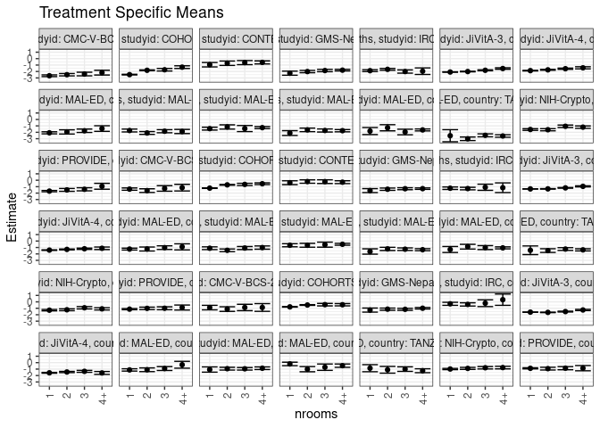

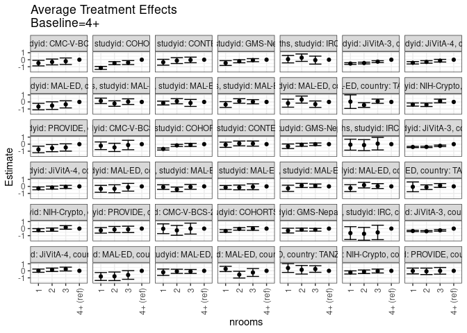

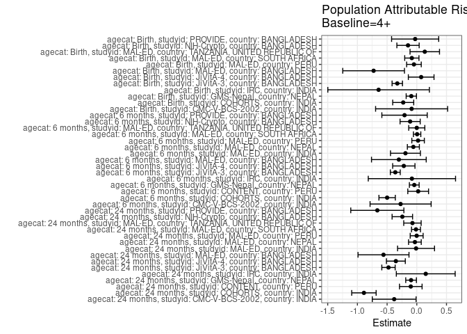

## Results Table

### Parameter: TSM

| agecat | studyid | country | intervention_level | baseline_level | estimate | ci_lower | ci_upper |
| --- | --- | --- | --- | --- | --- | --- | --- |
| Birth | CMC-V-BCS-2002 | INDIA | 4+ | NA | -0.8740000 | -1.4739904 | -0.2740096 |
| Birth | CMC-V-BCS-2002 | INDIA | 1 | NA | -0.8946053 | -1.2459292 | -0.5432813 |
| Birth | CMC-V-BCS-2002 | INDIA | 2 | NA | -1.1229310 | -1.4808250 | -0.7650370 |
| Birth | CMC-V-BCS-2002 | INDIA | 3 | NA | -0.8750000 | -1.3685904 | -0.3814096 |
| Birth | COHORTS | INDIA | 4+ | NA | -0.4490217 | -0.6274651 | -0.2705784 |
| Birth | COHORTS | INDIA | 1 | NA | -0.7804544 | -0.8208256 | -0.7400832 |
| Birth | COHORTS | INDIA | 2 | NA | -0.4904910 | -0.5505361 | -0.4304459 |
| Birth | COHORTS | INDIA | 3 | NA | -0.4352695 | -0.6287603 | -0.2417787 |
| Birth | GMS-Nepal | NEPAL | 4+ | NA | -0.9927103 | -1.1110675 | -0.8743531 |
| Birth | GMS-Nepal | NEPAL | 1 | NA | -1.2781633 | -1.5940216 | -0.9623050 |
| Birth | GMS-Nepal | NEPAL | 2 | NA | -1.1340690 | -1.3042878 | -0.9638502 |
| Birth | GMS-Nepal | NEPAL | 3 | NA | -1.1576796 | -1.3127013 | -1.0026579 |
| Birth | IRC | INDIA | 4+ | NA | 0.3352941 | -0.5439061 | 1.2144943 |
| Birth | IRC | INDIA | 1 | NA | -0.3042286 | -0.5400538 | -0.0684033 |
| Birth | IRC | INDIA | 2 | NA | -0.4001863 | -0.6508688 | -0.1495038 |
| Birth | IRC | INDIA | 3 | NA | -0.2084848 | -0.7339300 | 0.3169603 |
| Birth | JiVitA-3 | BANGLADESH | 4+ | NA | -1.2612715 | -1.3506213 | -1.1719218 |
| Birth | JiVitA-3 | BANGLADESH | 1 | NA | -1.5972522 | -1.6201771 | -1.5743273 |
| Birth | JiVitA-3 | BANGLADESH | 2 | NA | -1.6391242 | -1.6733849 | -1.6048635 |
| Birth | JiVitA-3 | BANGLADESH | 3 | NA | -1.5138441 | -1.5754568 | -1.4522314 |
| Birth | JiVitA-4 | BANGLADESH | 4+ | NA | -1.5973437 | -1.8190098 | -1.3756777 |
| Birth | JiVitA-4 | BANGLADESH | 1 | NA | -1.5768094 | -1.6401621 | -1.5134567 |
| Birth | JiVitA-4 | BANGLADESH | 2 | NA | -1.4506488 | -1.5464770 | -1.3548206 |
| Birth | JiVitA-4 | BANGLADESH | 3 | NA | -1.3494964 | -1.5027315 | -1.1962614 |
| Birth | MAL-ED | BANGLADESH | 4+ | NA | -0.3258333 | -0.8579324 | 0.2062657 |
| Birth | MAL-ED | BANGLADESH | 1 | NA | -1.1290000 | -1.3081731 | -0.9498269 |
| Birth | MAL-ED | BANGLADESH | 2 | NA | -1.1030435 | -1.3908212 | -0.8152658 |
| Birth | MAL-ED | BANGLADESH | 3 | NA | -0.9152000 | -1.2192575 | -0.6111425 |
| Birth | MAL-ED | PERU | 4+ | NA | -0.8660748 | -1.0688651 | -0.6632844 |
| Birth | MAL-ED | PERU | 1 | NA | -1.0700000 | -1.4758983 | -0.6641017 |

[output cut: 138 more lines]

### Parameter: E(Y)

| agecat | studyid | country | intervention_level | baseline_level | estimate | ci_lower | ci_upper |
| --- | --- | --- | --- | --- | --- | --- | --- |
| Birth | CMC-V-BCS-2002 | INDIA | NA | NA | -0.9611957 | -1.1776967 | -0.7446946 |
| Birth | COHORTS | INDIA | NA | NA | -0.6777626 | -0.7107167 | -0.6448086 |
| Birth | GMS-Nepal | NEPAL | NA | NA | -1.0851580 | -1.1651811 | -1.0051350 |
| Birth | IRC | INDIA | NA | NA | -0.3079016 | -0.4694769 | -0.1463262 |
| Birth | JiVitA-3 | BANGLADESH | NA | NA | -1.5898426 | -1.6091216 | -1.5705636 |
| Birth | JiVitA-4 | BANGLADESH | NA | NA | -1.5236135 | -1.5727559 | -1.4744711 |
| Birth | MAL-ED | BANGLADESH | NA | NA | -1.0530516 | -1.1896058 | -0.9164975 |
| Birth | MAL-ED | PERU | NA | NA | -0.9141395 | -1.0364098 | -0.7918693 |
| Birth | MAL-ED | SOUTH AFRICA | NA | NA | -0.5523958 | -0.7550074 | -0.3497843 |
| Birth | MAL-ED | TANZANIA, UNITED REPUBLIC OF | NA | NA | -1.1225000 | -1.3335666 | -0.9114334 |
| Birth | NIH-Crypto | BANGLADESH | NA | NA | -0.9094945 | -0.9809370 | -0.8380521 |
| Birth | PROVIDE | BANGLADESH | NA | NA | -0.8851020 | -0.9601332 | -0.8100709 |
| 6 months | CMC-V-BCS-2002 | INDIA | NA | NA | -1.4234508 | -1.5645974 | -1.2823042 |
| 6 months | COHORTS | INDIA | NA | NA | -1.0413281 | -1.0740395 | -1.0086167 |
| 6 months | CONTENT | PERU | NA | NA | -0.2785256 | -0.4098735 | -0.1471776 |
| 6 months | GMS-Nepal | NEPAL | NA | NA | -1.3508392 | -1.4290633 | -1.2726152 |
| 6 months | IRC | INDIA | NA | NA | -1.2470123 | -1.3779341 | -1.1160906 |
| 6 months | JiVitA-3 | BANGLADESH | NA | NA | -1.3132988 | -1.3364412 | -1.2901565 |
| 6 months | JiVitA-4 | BANGLADESH | NA | NA | -1.3440477 | -1.3813060 | -1.3067894 |
| 6 months | MAL-ED | BANGLADESH | NA | NA | -1.2026806 | -1.3203025 | -1.0850586 |
| 6 months | MAL-ED | INDIA | NA | NA | -1.2070638 | -1.3255909 | -1.0885368 |
| 6 months | MAL-ED | NEPAL | NA | NA | -0.5615819 | -0.6741832 | -0.4489807 |
| 6 months | MAL-ED | PERU | NA | NA | -1.3248549 | -1.4336721 | -1.2160378 |
| 6 months | MAL-ED | SOUTH AFRICA | NA | NA | -1.0547925 | -1.1843544 | -0.9252306 |
| 6 months | MAL-ED | TANZANIA, UNITED REPUBLIC OF | NA | NA | -1.3687449 | -1.4907629 | -1.2467270 |
| 6 months | NIH-Crypto | BANGLADESH | NA | NA | -1.1986783 | -1.2700937 | -1.1272630 |
| 6 months | PROVIDE | BANGLADESH | NA | NA | -1.0916915 | -1.1661176 | -1.0172654 |
| 24 months | CMC-V-BCS-2002 | INDIA | NA | NA | -2.5588679 | -2.6583730 | -2.4593629 |
| 24 months | COHORTS | INDIA | NA | NA | -2.2131714 | -2.2523749 | -2.1739679 |
| 24 months | CONTENT | PERU | NA | NA | -0.6868598 | -0.8388476 | -0.5348719 |
| 24 months | GMS-Nepal | NEPAL | NA | NA | -1.8874180 | -1.9728588 | -1.8019773 |
| 24 months | IRC | INDIA | NA | NA | -1.8014906 | -1.8952579 | -1.7077232 |
| 24 months | JiVitA-3 | BANGLADESH | NA | NA | -2.0137471 | -2.0414306 | -1.9860636 |
| 24 months | JiVitA-4 | BANGLADESH | NA | NA | -1.7803708 | -1.8158650 | -1.7448765 |
| 24 months | MAL-ED | BANGLADESH | NA | NA | -1.9783962 | -2.1050210 | -1.8517715 |
| 24 months | MAL-ED | INDIA | NA | NA | -1.8861894 | -2.0110006 | -1.7613783 |
| 24 months | MAL-ED | NEPAL | NA | NA | -1.3075877 | -1.4270718 | -1.1881037 |
| 24 months | MAL-ED | PERU | NA | NA | -1.7524710 | -1.8736426 | -1.6312994 |
| 24 months | MAL-ED | SOUTH AFRICA | NA | NA | -1.6450595 | -1.7797240 | -1.5103950 |
| 24 months | MAL-ED | TANZANIA, UNITED REPUBLIC OF | NA | NA | -2.6455607 | -2.7807256 | -2.5103959 |
| 24 months | NIH-Crypto | BANGLADESH | NA | NA | -1.4412646 | -1.5249156 | -1.3576135 |
| 24 months | PROVIDE | BANGLADESH | NA | NA | -1.6024221 | -1.6857420 | -1.5191023 |

### Parameter: ATE

| agecat | studyid | country | intervention_level | baseline_level | estimate | ci_lower | ci_upper |
| --- | --- | --- | --- | --- | --- | --- | --- |
| Birth | CMC-V-BCS-2002 | INDIA | 4+ | 4+ | 0.0000000 | 0.0000000 | 0.0000000 |
| Birth | CMC-V-BCS-2002 | INDIA | 1 | 4+ | -0.0206053 | -0.7158872 | 0.6746767 |
| Birth | CMC-V-BCS-2002 | INDIA | 2 | 4+ | -0.2489310 | -0.9475558 | 0.4496938 |
| Birth | CMC-V-BCS-2002 | INDIA | 3 | 4+ | -0.0010000 | -0.7779299 | 0.7759299 |
| Birth | COHORTS | INDIA | 4+ | 4+ | 0.0000000 | 0.0000000 | 0.0000000 |
| Birth | COHORTS | INDIA | 1 | 4+ | -0.3314327 | -0.5143859 | -0.1484795 |
| Birth | COHORTS | INDIA | 2 | 4+ | -0.0414692 | -0.2297442 | 0.1468057 |
| Birth | COHORTS | INDIA | 3 | 4+ | 0.0137523 | -0.2494600 | 0.2769646 |
| Birth | GMS-Nepal | NEPAL | 4+ | 4+ | 0.0000000 | 0.0000000 | 0.0000000 |
| Birth | GMS-Nepal | NEPAL | 1 | 4+ | -0.2854530 | -0.6227583 | 0.0518523 |
| Birth | GMS-Nepal | NEPAL | 2 | 4+ | -0.1413587 | -0.3486818 | 0.0659644 |
| Birth | GMS-Nepal | NEPAL | 3 | 4+ | -0.1649693 | -0.3600081 | 0.0300696 |
| Birth | IRC | INDIA | 4+ | 4+ | 0.0000000 | 0.0000000 | 0.0000000 |
| Birth | IRC | INDIA | 1 | 4+ | -0.6395227 | -1.5498010 | 0.2707556 |
| Birth | IRC | INDIA | 2 | 4+ | -0.7354805 | -1.6497204 | 0.1787595 |
| Birth | IRC | INDIA | 3 | 4+ | -0.5437790 | -1.5680277 | 0.4804698 |
| Birth | JiVitA-3 | BANGLADESH | 4+ | 4+ | 0.0000000 | 0.0000000 | 0.0000000 |
| Birth | JiVitA-3 | BANGLADESH | 1 | 4+ | -0.3359807 | -0.4277848 | -0.2441765 |
| Birth | JiVitA-3 | BANGLADESH | 2 | 4+ | -0.3778527 | -0.4724702 | -0.2832352 |
| Birth | JiVitA-3 | BANGLADESH | 3 | 4+ | -0.2525726 | -0.3602193 | -0.1449259 |
| Birth | JiVitA-4 | BANGLADESH | 4+ | 4+ | 0.0000000 | 0.0000000 | 0.0000000 |
| Birth | JiVitA-4 | BANGLADESH | 1 | 4+ | 0.0205344 | -0.2086136 | 0.2496824 |
| Birth | JiVitA-4 | BANGLADESH | 2 | 4+ | 0.1466949 | -0.0940721 | 0.3874620 |
| Birth | JiVitA-4 | BANGLADESH | 3 | 4+ | 0.2478473 | -0.0239857 | 0.5196804 |
| Birth | MAL-ED | BANGLADESH | 4+ | 4+ | 0.0000000 | 0.0000000 | 0.0000000 |
| Birth | MAL-ED | BANGLADESH | 1 | 4+ | -0.8031667 | -1.3646223 | -0.2417111 |
| Birth | MAL-ED | BANGLADESH | 2 | 4+ | -0.7772101 | -1.3821443 | -0.1722759 |
| Birth | MAL-ED | BANGLADESH | 3 | 4+ | -0.5893667 | -1.2022128 | 0.0234794 |
| Birth | MAL-ED | PERU | 4+ | 4+ | 0.0000000 | 0.0000000 | 0.0000000 |
| Birth | MAL-ED | PERU | 1 | 4+ | -0.2039252 | -0.6576623 | 0.2498118 |

[output cut: 138 more lines]

### Parameter: PAR

| agecat | studyid | country | intervention_level | baseline_level | estimate | ci_lower | ci_upper |
| --- | --- | --- | --- | --- | --- | --- | --- |
| Birth | CMC-V-BCS-2002 | INDIA | 4+ | NA | -0.0871957 | -0.6936048 | 0.5192134 |
| Birth | COHORTS | INDIA | 4+ | NA | -0.2287409 | -0.4057604 | -0.0517214 |
| Birth | GMS-Nepal | NEPAL | 4+ | NA | -0.0924478 | -0.1789957 | -0.0058998 |
| Birth | IRC | INDIA | 4+ | NA | -0.6431957 | -1.4981881 | 0.2117968 |
| Birth | JiVitA-3 | BANGLADESH | 4+ | NA | -0.3285711 | -0.4161933 | -0.2409489 |
| Birth | JiVitA-4 | BANGLADESH | 4+ | NA | 0.0737303 | -0.1424289 | 0.2898894 |
| Birth | MAL-ED | BANGLADESH | 4+ | NA | -0.7272183 | -1.2467128 | -0.2077238 |
| Birth | MAL-ED | PERU | 4+ | NA | -0.0480648 | -0.1711147 | 0.0749852 |
| Birth | MAL-ED | SOUTH AFRICA | 4+ | NA | -0.0835899 | -0.2035080 | 0.0363283 |
| Birth | MAL-ED | TANZANIA, UNITED REPUBLIC OF | 4+ | NA | 0.1342347 | -0.1139344 | 0.3824038 |
| Birth | NIH-Crypto | BANGLADESH | 4+ | NA | -0.1478816 | -0.3355905 | 0.0398272 |
| Birth | PROVIDE | BANGLADESH | 4+ | NA | -0.0277336 | -0.4243938 | 0.3689265 |
| 6 months | CMC-V-BCS-2002 | INDIA | 4+ | NA | -0.2727365 | -0.7868576 | 0.2413846 |
| 6 months | COHORTS | INDIA | 4+ | NA | -0.4996077 | -0.6374107 | -0.3618046 |
| 6 months | CONTENT | PERU | 4+ | NA | 0.0231411 | -0.1516652 | 0.1979474 |
| 6 months | GMS-Nepal | NEPAL | 4+ | NA | -0.0425557 | -0.1246308 | 0.0395195 |
| 6 months | IRC | INDIA | 4+ | NA | -0.0825025 | -0.8172636 | 0.6522585 |
| 6 months | JiVitA-3 | BANGLADESH | 4+ | NA | -0.3622235 | -0.4456442 | -0.2788029 |
| 6 months | JiVitA-4 | BANGLADESH | 4+ | NA | -0.2186278 | -0.4063979 | -0.0308578 |
| 6 months | MAL-ED | BANGLADESH | 4+ | NA | -0.3019861 | -0.7625584 | 0.1585862 |
| 6 months | MAL-ED | INDIA | 4+ | NA | -0.1911305 | -0.4428563 | 0.0605953 |
| 6 months | MAL-ED | NEPAL | 4+ | NA | -0.0578033 | -0.1588533 | 0.0432467 |
| 6 months | MAL-ED | PERU | 4+ | NA | 0.0215779 | -0.0837772 | 0.1269330 |
| 6 months | MAL-ED | SOUTH AFRICA | 4+ | NA | 0.0053471 | -0.0567864 | 0.0674806 |
| 6 months | MAL-ED | TANZANIA, UNITED REPUBLIC OF | 4+ | NA | -0.0003807 | -0.1360002 | 0.1352387 |
| 6 months | NIH-Crypto | BANGLADESH | 4+ | NA | -0.1123596 | -0.2818458 | 0.0571266 |
| 6 months | PROVIDE | BANGLADESH | 4+ | NA | -0.2064534 | -0.5884406 | 0.1755338 |
| 24 months | CMC-V-BCS-2002 | INDIA | 4+ | NA | -0.3806536 | -0.7496382 | -0.0116690 |
| 24 months | COHORTS | INDIA | 4+ | NA | -0.8902766 | -1.0959590 | -0.6845943 |
| 24 months | CONTENT | PERU | 4+ | NA | -0.1012248 | -0.2914026 | 0.0889529 |
| 24 months | GMS-Nepal | NEPAL | 4+ | NA | -0.0962997 | -0.1863140 | -0.0062854 |
| 24 months | IRC | INDIA | 4+ | NA | 0.1507643 | -0.3446235 | 0.6461522 |
| 24 months | JiVitA-3 | BANGLADESH | 4+ | NA | -0.4766899 | -0.5891145 | -0.3642653 |
| 24 months | JiVitA-4 | BANGLADESH | 4+ | NA | -0.3524026 | -0.5113434 | -0.1934619 |
| 24 months | MAL-ED | BANGLADESH | 4+ | NA | -0.5606690 | -0.9897923 | -0.1315456 |
| 24 months | MAL-ED | INDIA | 4+ | NA | -0.0125894 | -0.3238384 | 0.2986596 |
| 24 months | MAL-ED | NEPAL | 4+ | NA | -0.0319578 | -0.1386452 | 0.0747296 |
| 24 months | MAL-ED | PERU | 4+ | NA | -0.0021225 | -0.1108609 | 0.1066159 |
| 24 months | MAL-ED | SOUTH AFRICA | 4+ | NA | -0.0138437 | -0.0890987 | 0.0614114 |
| 24 months | MAL-ED | TANZANIA, UNITED REPUBLIC OF | 4+ | NA | -0.0733158 | -0.2199439 | 0.0733122 |
| 24 months | NIH-Crypto | BANGLADESH | 4+ | NA | -0.2435817 | -0.4159507 | -0.0712127 |
| 24 months | PROVIDE | BANGLADESH | 4+ | NA | -0.6646949 | -1.1118811 | -0.2175086 |